# Vignette: tweets-class

# rtweet

## Package Philosophy

Coming from the communication field—where there is an abundance of critical and analytical thinking and a shortage of computer programming—it’s important to me that anyone interested in researching Twitter can feel relatively comfortable approaching data collected via Twitter’s APIs.

Accordingly, the philosophy behind `rtweet` is simple. It is to make Twitter data more accessible to more people.

```
rtweet philosophy: make Twitter data more accessible to more people.
```

After talking with my Computing and Statistics professor, I think I’ve narrowed in on some things about `rtweet` I want to keep simple and clear. Unfortunately for the R-nerd in me, that means—at least, for the time being—giving up on S4 classes and methods. While new classes and methods would have been cool, I don’t think it would have added a lot of functionality. And, if anything, I think it would have detracted from the central purpose of rtweet, which I described above.

So, I’ve created this document for two reasons. First, because I wanted to communicate the philosophy behind the package. Second, because I wanted to send off my S4 work in style. And what better way is there to say goodbye than to say it on a classy rmarkdown vignette.

## Classes

```r
library(rtweet)
mk <- get_favorites("kearneymw", n = 2000)

# create object of tweets class
mk_s4 <- make_tweets(mk)
class(mk_s4)
```

```
## [1] "tweets"
## attr(,"package")
## [1] "rtweet"
```

```r
# print (show) method for tweets
mk_s4
```

```
## tweets-class [rtweet]
##  788 tweets (rows) x 23 variables (columns)
##
## Variable Names:
##   created_at                  source
##       user_id                     lang
##       screen_name                 mentions_user_id
##       status_id                   mentions_screen_name
##       retweet_count               hashtags
##       favorite_count              urls
##       text                        is_retweet
##       in_reply_to_status_id       retweet_status_id
##       in_reply_to_user_id         place_name
##       in_reply_to_screen_name     country
##       is_quote_status             coordinates
##       quoted_status_id
##
## Number of unique users = 224
## Number of retweet statuses = 0
## Number of quote statuses = 102
## Average number of favorites = 527
## Average number of retweets = 310
## Total number of hashtags = 839
## Total number of mentions = 905
## First tweet = [1] "2016-06-25 10:43:42 CDT"
## Last tweet = [1] "2016-09-19 18:06:19 CDT"
##
## Preview:
##      date        screen_name      rtweets  favorites  hashtags
## 1    2016-08-27  HoloMarkeD            3        7     NA
## 2    2016-07-27  SethGannon            3       11     NA
## 3    2016-08-03  olneyce               0        1     NA
## 4    2016-07-27  olneyce               0        2     NA
## 5    2016-08-03  olneyce               0        1     NA
##      text
## 1    My first code coverage working on Travis https://t.co/rYCC5a..
## 2    Mr. Gorbachev, tear down this firewall.
## 3    11/ Imagine an Alec Baldwin who has descended into caricatur..
## 4    @kearneymw It was irritatingly mealy-mouthed, but way way wa..
## 5    4/ In a way, Clintons competence is a strike against her. A ..
##  [ reached getOption("max.print") -- omitted 783 rows ]
```

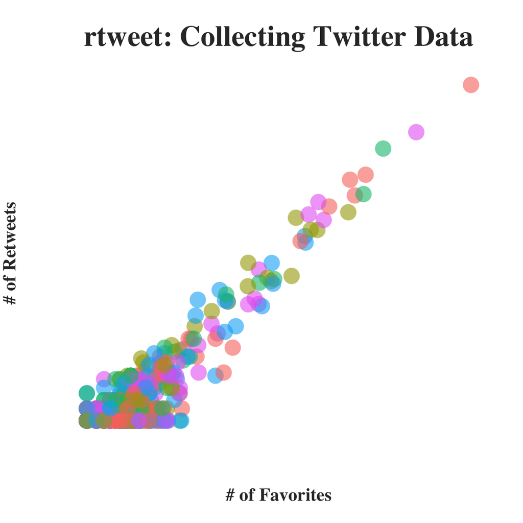

```r
# plot method for tweets
plot(mk_s4)
```

```r
# another example
tw <- search_tweets("rstats", n = 500, dev = TRUE)
```

```
## Searching for tweets...
```

```
## Finished collecting tweets!
```

```r
tw
```

```
## tweets-class [rtweet]
##  504 tweets (rows) x 23 variables (columns)
##
## Variable Names:
##   created_at                  source
##       user_id                     lang
##       screen_name                 mentions_user_id
##       status_id                   mentions_screen_name
##       retweet_count               hashtags
##       favorite_count              urls
##       text                        is_retweet
##       in_reply_to_status_id       retweet_status_id
##       in_reply_to_user_id         place_name
##       in_reply_to_screen_name     country
##       is_quote_status             coordinates
##       quoted_status_id
##
## Number of unique users = 423
## Number of retweet statuses = 320
## Number of quote statuses = 44
## Average number of favorites = 2
## Average number of retweets = 14
## Total number of hashtags = 934
## Total number of mentions = 639
## First tweet = [1] "2016-09-15 11:56:34 CDT"
## Last tweet = [1] "2016-09-19 20:20:02 CDT"
##
## Preview:
##      date        screen_name      rtweets  favorites  hashtags
## 1    2016-09-19  solutions           0       4        spark, rst..
## 2    2016-09-19  kimu               12       0        rstats
## 3    2016-09-19  rikturr             0       0        rstats
## 4    2016-09-19  CiaraWhiteHorn     12       0        diversity,..
## 5    <NA>        <NA>               NA      NA        NULL
##      text
## 1    7 Steps to Mastering Apache Spark 2.0 https://t.co/5DQdZatfj..
## 2    RT @_mikoontz: Whats a pirates  computer language? \\n\\nYoud ..
## 3    so NA is not NULL. wut #rstats
## 4    RT @RallidaeRule: On @biotweeps this week well talk about #d..
## 5    <NA>
##  [ reached getOption("max.print") -- omitted 524 rows ]
```

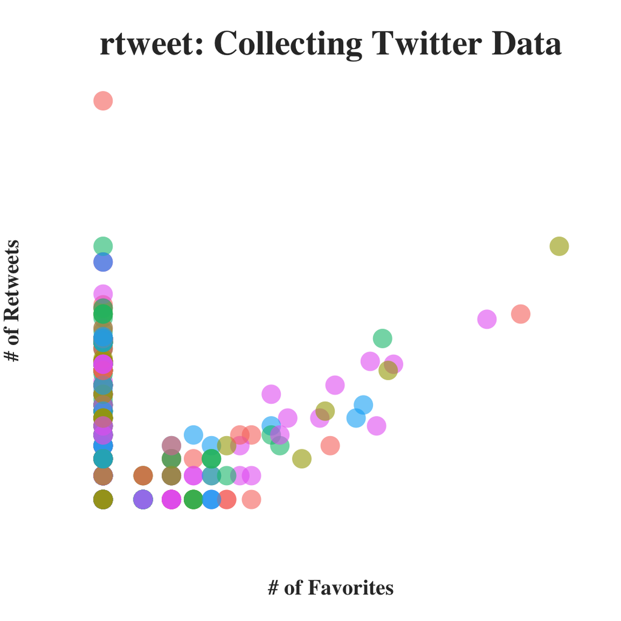

```r
plot(tw)
```

The plot is clearly gratuitous, but it was just supposed to be a placeholder. I think I’ll store these classes in the package for now and maybe revisit the idea down the road, but they won’t be integrated into functions any time soon.